# Predict Bike Sharing Demand with AutoGluon Template

## Project: Predict Bike Sharing Demand with AutoGluon

This notebook is a template with each step that you need to complete for the project.

Please fill in your code where there are explicit `?` markers in the notebook. You are welcome to add more cells and code as you see fit.

Once you have completed all the code implementations, please export your notebook as a HTML file so the reviews can view your code. Make sure you have all outputs correctly outputted.

`File-> Export Notebook As... -> Export Notebook as HTML`

There is a writeup to complete as well after all code implememtation is done. Please answer all questions and attach the necessary tables and charts. You can complete the writeup in either markdown or PDF.

Completing the code template and writeup template will cover all of the rubric points for this project.

The rubric contains "Stand Out Suggestions" for enhancing the project beyond the minimum requirements. The stand out suggestions are optional. If you decide to pursue the "stand out suggestions", you can include the code in this notebook and also discuss the results in the writeup file.

## Step 1: Create an account with Kaggle

### Create Kaggle Account and download API key

Below is example of steps to get the API username and key. Each student will have their own username and key.

1. Open account settings.

2. Scroll down to API and click Create New API Token.

3. Open up `kaggle.json` and use the username and key.


## Step 2: Download the Kaggle dataset using the kaggle python library

### Open up Sagemaker Studio and use starter template

1. Notebook should be using a `ml.t3.medium` instance (2 vCPU + 4 GiB)
2. Notebook should be using kernal: `Python 3 (MXNet 1.8 Python 3.7 CPU Optimized)`

### Setup Kaggle API Key

```python
!conda activate py310
!conda env list
```

```
# conda environments:
#
base                  *  C:\Users\gesrgiorgi\AppData\Local\anaconda3
py310                    C:\Users\gesrgiorgi\AppData\Local\anaconda3\envs\py310
```

```python
import os
os.path.abspath("")
```

```
'C:\\Users\\gesrgiorgi\\OneDrive - Cassa Depositi e Prestiti\\Documenti\\nd009t-c1-intro-to-ml-project-starter'
```

```python
# Fill in your user name and key from creating the kaggle account and API token file
import json
kaggle_username = "giorgirob"
kaggle_key = "6b65273643c252db1705f5dcb66873c6"

# Save API token the kaggle.json file
with open(".kaggle/kaggle.json", "w") as f:
    f.write(json.dumps({"username": kaggle_username, "key": kaggle_key}))
```

### Download and explore dataset

```python
import pandas as pd
from autogluon.tabular import TabularPredictor
```

```python
# Create the train dataset in pandas by reading the csv
# Set the parsing of the datetime column so you can use some of the `dt` features in pandas later
train = pd.read_csv('train.csv', parse_dates=['datetime'])
train.head()
```

|  | datetime | season | holiday | workingday | weather | temp | atemp | humidity | windspeed | casual | registered | count |
| --- | --- | --- | --- | --- | --- | --- | --- | --- | --- | --- | --- | --- |
| 0 | 2011-01-01 00:00:00 | 1 | 0 | 0 | 1 | 9.84 | 14.395 | 81 | 0.0 | 3 | 13 | 16 |
| 1 | 2011-01-01 01:00:00 | 1 | 0 | 0 | 1 | 9.02 | 13.635 | 80 | 0.0 | 8 | 32 | 40 |
| 2 | 2011-01-01 02:00:00 | 1 | 0 | 0 | 1 | 9.02 | 13.635 | 80 | 0.0 | 5 | 27 | 32 |
| 3 | 2011-01-01 03:00:00 | 1 | 0 | 0 | 1 | 9.84 | 14.395 | 75 | 0.0 | 3 | 10 | 13 |
| 4 | 2011-01-01 04:00:00 | 1 | 0 | 0 | 1 | 9.84 | 14.395 | 75 | 0.0 | 0 | 1 | 1 |

```python
# Simple output of the train dataset to view some of the min/max/varition of the dataset features.
train.describe()
```

|  | datetime | season | holiday | workingday | weather | temp | atemp | humidity | windspeed | casual | registered | count |
| --- | --- | --- | --- | --- | --- | --- | --- | --- | --- | --- | --- | --- |
| count | 10886 | 10886.000000 | 10886.000000 | 10886.000000 | 10886.000000 | 10886.00000 | 10886.000000 | 10886.000000 | 10886.000000 | 10886.000000 | 10886.000000 | 10886.000000 |
| mean | 2011-12-27 05:56:22.399411968 | 2.506614 | 0.028569 | 0.680875 | 1.418427 | 20.23086 | 23.655084 | 61.886460 | 12.799395 | 36.021955 | 155.552177 | 191.574132 |
| min | 2011-01-01 00:00:00 | 1.000000 | 0.000000 | 0.000000 | 1.000000 | 0.82000 | 0.760000 | 0.000000 | 0.000000 | 0.000000 | 0.000000 | 1.000000 |
| 25% | 2011-07-02 07:15:00 | 2.000000 | 0.000000 | 0.000000 | 1.000000 | 13.94000 | 16.665000 | 47.000000 | 7.001500 | 4.000000 | 36.000000 | 42.000000 |
| 50% | 2012-01-01 20:30:00 | 3.000000 | 0.000000 | 1.000000 | 1.000000 | 20.50000 | 24.240000 | 62.000000 | 12.998000 | 17.000000 | 118.000000 | 145.000000 |
| 75% | 2012-07-01 12:45:00 | 4.000000 | 0.000000 | 1.000000 | 2.000000 | 26.24000 | 31.060000 | 77.000000 | 16.997900 | 49.000000 | 222.000000 | 284.000000 |
| max | 2012-12-19 23:00:00 | 4.000000 | 1.000000 | 1.000000 | 4.000000 | 41.00000 | 45.455000 | 100.000000 | 56.996900 | 367.000000 | 886.000000 | 977.000000 |
| std | NaN | 1.116174 | 0.166599 | 0.466159 | 0.633839 | 7.79159 | 8.474601 | 19.245033 | 8.164537 | 49.960477 | 151.039033 | 181.144454 |

```python
# Create the test pandas dataframe in pandas by reading the csv, remember to parse the datetime!
test = pd.read_csv('test.csv', parse_dates=['datetime'])
test.head()
```

|  | datetime | season | holiday | workingday | weather | temp | atemp | humidity | windspeed |
| --- | --- | --- | --- | --- | --- | --- | --- | --- | --- |
| 0 | 2011-01-20 00:00:00 | 1 | 0 | 1 | 1 | 10.66 | 11.365 | 56 | 26.0027 |
| 1 | 2011-01-20 01:00:00 | 1 | 0 | 1 | 1 | 10.66 | 13.635 | 56 | 0.0000 |
| 2 | 2011-01-20 02:00:00 | 1 | 0 | 1 | 1 | 10.66 | 13.635 | 56 | 0.0000 |
| 3 | 2011-01-20 03:00:00 | 1 | 0 | 1 | 1 | 10.66 | 12.880 | 56 | 11.0014 |
| 4 | 2011-01-20 04:00:00 | 1 | 0 | 1 | 1 | 10.66 | 12.880 | 56 | 11.0014 |

```python
# Same thing as train and test dataset
submission = pd.read_csv('sampleSubmission.csv')
submission.head()
```

|  | datetime | count |
| --- | --- | --- |
| 0 | 2011-01-20 00:00:00 | 0 |
| 1 | 2011-01-20 01:00:00 | 0 |
| 2 | 2011-01-20 02:00:00 | 0 |
| 3 | 2011-01-20 03:00:00 | 0 |
| 4 | 2011-01-20 04:00:00 | 0 |

## Step 3: Train a model using AutoGluon’s Tabular Prediction

Requirements:

- We are predicting `count`, so it is the label we are setting.
- Ignore `casual` and `registered` columns as they are also not present in the test dataset.
- Use the `root_mean_squared_error` as the metric to use for evaluation.
- Set a time limit of 10 minutes (600 seconds).
- Use the preset `best_quality` to focus on creating the best model.

```python
print(train.columns)
```

```
Index(['datetime', 'season', 'holiday', 'workingday', 'weather', 'temp',
       'atemp', 'humidity', 'windspeed', 'casual', 'registered', 'count'],
      dtype='object')
```

```python
# First I'm gomma remove registered and casual columns
df_train_column = train.columns.to_list()
df_train_column.remove('casual')
df_train_column.remove('registered')

# Then I update the dataframe without these columns and display the dataframe updated
df_train = train[df_train_column]
df_train.head()
```

|  | datetime | season | holiday | workingday | weather | temp | atemp | humidity | windspeed | count |
| --- | --- | --- | --- | --- | --- | --- | --- | --- | --- | --- |
| 0 | 2011-01-01 00:00:00 | 1 | 0 | 0 | 1 | 9.84 | 14.395 | 81 | 0.0 | 16 |
| 1 | 2011-01-01 01:00:00 | 1 | 0 | 0 | 1 | 9.02 | 13.635 | 80 | 0.0 | 40 |
| 2 | 2011-01-01 02:00:00 | 1 | 0 | 0 | 1 | 9.02 | 13.635 | 80 | 0.0 | 32 |
| 3 | 2011-01-01 03:00:00 | 1 | 0 | 0 | 1 | 9.84 | 14.395 | 75 | 0.0 | 13 |
| 4 | 2011-01-01 04:00:00 | 1 | 0 | 0 | 1 | 9.84 | 14.395 | 75 | 0.0 | 1 |

```python
# I prepare the predictor (tuple) with the information needed
predictor = TabularPredictor(
    label='count',
    problem_type='regression',
    eval_metric='root_mean_squared_error').fit(
    train_data=df_train,
    time_limit=600,
    presets='best_quality',)
```

```
No path specified. Models will be saved in: "AutogluonModels\ag-20240511_141012"
Presets specified: ['best_quality']
Setting dynamic_stacking from 'auto' to True. Reason: Enable dynamic_stacking when use_bag_holdout is disabled. (use_bag_holdout=False)
Stack configuration (auto_stack=True): num_stack_levels=1, num_bag_folds=8, num_bag_sets=1
Dynamic stacking is enabled (dynamic_stacking=True). AutoGluon will try to determine whether the input data is affected by stacked overfitting and enable or disable stacking as a consequence.
Detecting stacked overfitting by sub-fitting AutoGluon on the input data. That is, copies of AutoGluon will be sub-fit on subset(s) of the data. Then, the holdout validation data is used to detect stacked overfitting.
Sub-fit(s) time limit is: 600 seconds.
Starting holdout-based sub-fit for dynamic stacking. Context path is: AutogluonModels\ag-20240511_141012\ds_sub_fit\sub_fit_ho.
Running the sub-fit in a ray process to avoid memory leakage.
Spend 180 seconds for the sub-fit(s) during dynamic stacking.
Time left for full fit of AutoGluon: 420 seconds.
Starting full fit now with num_stack_levels 1.
Beginning AutoGluon training ... Time limit = 420s
AutoGluon will save models to "AutogluonModels\ag-20240511_141012"
=================== System Info ===================
AutoGluon Version:  1.1.0
Python Version:     3.10.6
Operating System:   Windows
Platform Machine:   AMD64
Platform Version:   10.0.19045
CPU Count:          8
Memory Avail:       7.95 GB / 15.82 GB (50.3%)
Disk Space Avail:   148.81 GB / 235.46 GB (63.2%)
===================================================
Train Data Rows:    10886
Train Data Columns: 9
Label Column:       count
Problem Type:       regression
Preprocessing data ...
Using Feature Generators to preprocess the data ...
Fitting AutoMLPipelineFeatureGenerator...
	Available Memory:                    8144.11 MB
	Train Data (Original)  Memory Usage: 0.75 MB (0.0% of available memory)
	Inferring data type of each feature based on column values. Set feature_metadata_in to manually specify special dtypes of the features.
	Stage 1 Generators:
		Fitting AsTypeFeatureGenerator...
			Note: Converting 2 features to boolean dtype as they only contain 2 unique values.
	Stage 2 Generators:
		Fitting FillNaFeatureGenerator...
	Stage 3 Generators:
```

[output cut: 89 more lines]

```
	-53.434	 = Validation score   (-root_mean_squared_error)
	17.8s	 = Training   runtime
	0.71s	 = Validation runtime
Fitting model: CatBoost_BAG_L2 ... Training model for up to 51.33s of the 51.16s of remaining time.
	Fitting 8 child models (S1F1 - S1F8) | Fitting with ParallelLocalFoldFittingStrategy (8 workers, per: cpus=1, gpus=0, memory=0.19%)
	-55.5836	 = Validation score   (-root_mean_squared_error)
	45.27s	 = Training   runtime
	0.2s	 = Validation runtime
Fitting model: WeightedEnsemble_L3 ... Training model for up to 360.0s of the -5.67s of remaining time.
	Ensemble Weights: {'RandomForestMSE_BAG_L2': 0.682, 'LightGBM_BAG_L2': 0.182, 'CatBoost_BAG_L2': 0.136}
	-53.1059	 = Validation score   (-root_mean_squared_error)
	0.06s	 = Training   runtime
	0.0s	 = Validation runtime
AutoGluon training complete, total runtime = 425.81s ... Best model: "WeightedEnsemble_L3"
TabularPredictor saved. To load, use: predictor = TabularPredictor.load("AutogluonModels\ag-20240511_141012")
```

### Review AutoGluon's training run with ranking of models that did the best.

```python
!pip install bokeh==2.0.1
```

```python
# Review AutoGluon's training run
predictor.fit_summary()
```

```
*** Summary of fit() ***
Estimated performance of each model:
                     model   score_val              eval_metric  pred_time_val    fit_time  pred_time_val_marginal  fit_time_marginal  stack_level  can_infer  fit_order
0      WeightedEnsemble_L3  -53.105916  root_mean_squared_error      18.432291  321.633095                0.000999           0.063940            3       True         14
1   RandomForestMSE_BAG_L2  -53.433961  root_mean_squared_error      17.845310  269.680924                0.710123          17.804307            2       True         12
2          LightGBM_BAG_L2  -55.056827  root_mean_squared_error      17.522873  258.494666                0.387686           6.618049            2       True         11
3          CatBoost_BAG_L2  -55.583615  root_mean_squared_error      17.333482  297.146799                0.198295          45.270182            2       True         13
4        LightGBMXT_BAG_L2  -60.384669  root_mean_squared_error      22.861250  269.998095                5.726063          18.121478            2       True         10
5      WeightedEnsemble_L2  -84.146423  root_mean_squared_error       0.068485    0.203264                0.000000           0.089103            2       True          9
6    KNeighborsDist_BAG_L1  -84.146423  root_mean_squared_error       0.068485    0.114161                0.068485           0.114161            1       True          2
7    KNeighborsUnif_BAG_L1 -101.588176  root_mean_squared_error       0.067925    0.113520                0.067925           0.113520            1       True          1
8   RandomForestMSE_BAG_L1 -116.552091  root_mean_squared_error       0.575173    6.805548                0.575173           6.805548            1       True          5
9     ExtraTreesMSE_BAG_L1 -124.602302  root_mean_squared_error       0.608714    3.406807                0.608714           3.406807            1       True          7
10         CatBoost_BAG_L1 -130.466966  root_mean_squared_error       0.179641  169.579838                0.179641         169.579838            1       True          6
11         LightGBM_BAG_L1 -131.054162  root_mean_squared_error       1.779414    8.954734                1.779414           8.954734            1       True          4
12       LightGBMXT_BAG_L1 -131.460909  root_mean_squared_error      13.278012   25.772945               13.278012          25.772945            1       True          3
13  NeuralNetFastAI_BAG_L1 -138.041083  root_mean_squared_error       0.577824   37.129064                0.577824          37.129064            1       True          8
Number of models trained: 14
Types of models trained:
{'StackerEnsembleModel_RF', 'StackerEnsembleModel_KNN', 'StackerEnsembleModel_NNFastAiTabular', 'WeightedEnsembleModel', 'StackerEnsembleModel_XT', 'StackerEnsembleModel_LGB', 'StackerEnsembleModel_CatBoost'}
Bagging used: True  (with 8 folds)
Multi-layer stack-ensembling used: True  (with 3 levels)
Feature Metadata (Processed):
(raw dtype, special dtypes):
('float', [])                : 3 | ['temp', 'atemp', 'windspeed']
('int', [])                  : 3 | ['season', 'weather', 'humidity']
('int', ['bool'])            : 2 | ['holiday', 'workingday']
('int', ['datetime_as_int']) : 5 | ['datetime', 'datetime.year', 'datetime.month', 'datetime.day', 'datetime.dayofweek']
*** End of fit() summary ***
```

[output not shown]

[output cut: 126 more lines]

```
     stack_level  can_infer  fit_order
 0             3       True         14
 1             2       True         12
 2             2       True         11
 3             2       True         13
 4             2       True         10
 5             2       True          9
 6             1       True          2
 7             1       True          1
 8             1       True          5
 9             1       True          7
 10            1       True          6
 11            1       True          4
 12            1       True          3
 13            1       True          8  }
```

### Create predictions from test dataset

```python
predictions = predictor.predict(test, as_pandas=True)
predictions.head()
```

```
0    23.411671
1    41.782013
2    46.642799
3    50.546059
4    52.479252
Name: count, dtype: float32
```

#### NOTE: Kaggle will reject the submission if we don't set everything to be > 0.

```python
# Describe the `predictions` series to see if there are any negative values
predictions.describe()
```

```
count    6493.000000
mean      100.767998
std        89.625282
min         3.149649
25%        20.330088
50%        64.765770
75%       166.632935
max       369.209656
Name: count, dtype: float64
```

```python
# How many negative values do we have?
negative_count = (predictions < 0).sum()
print("Number of negative values in predictions:", negative_count)
```

```
Number of negative values in predictions: 0
```

```python
# Set them to zero
predictions[predictions < 0] = 0
```

### Set predictions to submission dataframe, save, and submit

```python
submission["count"] = predictions
submission.to_csv("submission.csv", index=False)
```

```python
!kaggle competitions submit -c bike-sharing-demand -f submission.csv -m "first raw submission"
```

```
Successfully submitted to Bike Sharing Demand
```

```
  4%|4         | 8.00k/195k [00:00<00:12, 15.1kB/s]
```

#### View submission via the command line or in the web browser under the competition's page - `My Submissions`

```python
!kaggle competitions submissions -c bike-sharing-demand | tail -n +1 | head -n 6
```

[output not shown]

#### Initial score of `1.79947`

## Step 4: Exploratory Data Analysis and Creating an additional feature

- Any additional feature will do, but a great suggestion would be to separate out the datetime into hour, day, or month parts.

```
array([[<Axes: title={'center': 'datetime'}>,
        <Axes: title={'center': 'season'}>,
        <Axes: title={'center': 'holiday'}>],
       [<Axes: title={'center': 'workingday'}>,
        <Axes: title={'center': 'weather'}>,
        <Axes: title={'center': 'temp'}>],
       [<Axes: title={'center': 'atemp'}>,
        <Axes: title={'center': 'humidity'}>,
        <Axes: title={'center': 'windspeed'}>],
       [<Axes: title={'center': 'casual'}>,
        <Axes: title={'center': 'registered'}>,
        <Axes: title={'center': 'count'}>]], dtype=object)
```

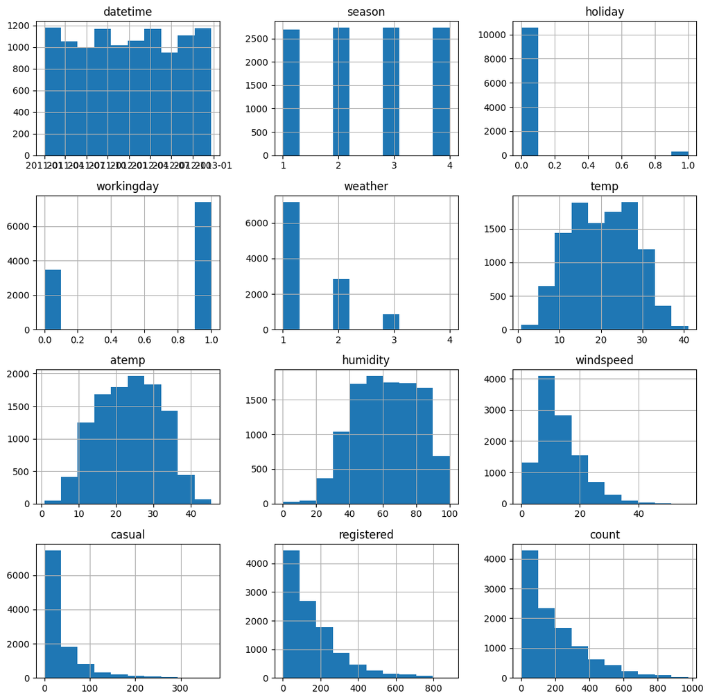

```python
# Create a histogram of all features to show the distribution of each one relative to the data. This is part of the exploritory data analysis
train.hist(figsize=(13, 13))
```

## Creating addictional feature by examing day time statics

```python
# Examining years available
print("years in training data : {}".format(train.datetime.dt.year.unique()))
print("years in test data : {}".format(test.datetime.dt.year.unique()))
print("####")

# Examining months available
print("Months available in training data : {}".format(train.datetime.dt.month.unique()))
print("Months available in test data : {}".format(test.datetime.dt.month.unique()))
print("####")

# Examining days available
print("Days available in training data : {}".format(train.datetime.dt.day.unique()))
print("Days available in test data : {}".format(test.datetime.dt.day.unique()))
print("####")

# Examining hours available
print("Hours available in training data : {}".format(train.datetime.dt.hour.unique()))
print("Hours available in test data : {}".format(test.datetime.dt.hour.unique()))
print("####")
```

```
years in training data : [2011 2012]
years in test data : [2011 2012]
####
Months available in training data : [ 1  2  3  4  5  6  7  8  9 10 11 12]
Months available in test data : [ 1  2  3  4  5  6  7  8  9 10 11 12]
####
Days available in training data : [ 1  2  3  4  5  6  7  8  9 10 11 12 13 14 15 16 17 18 19]
Days available in test data : [20 21 22 23 24 25 26 27 28 29 30 31]
####
Hours available in training data : [ 0  1  2  3  4  5  6  7  8  9 10 11 12 13 14 15 16 17 18 19 20 21 22 23]
Hours available in test data : [ 0  1  2  3  4  5  6  7  8  9 10 11 12 13 14 15 16 17 18 19 20 21 22 23]
####
```

```python
# create a new feature
train['hour'] = train['datetime'].dt.hour
test['hour'] = test['datetime'].dt.hour
```

## Make category types for these so models know they are not just numbers

- AutoGluon originally sees these as ints, but in reality they are int representations of a category.
- Setting the dtype to category will classify these as categories in AutoGluon.

```python
train['season'] = train['season'].astype('category')
train['weather'] = train['weather'].astype('category')
test['season'] = test['season'].astype('category')
test['weather'] = test['weather'].astype('category')
```

```python
# View are new feature
train.head()
```

|  | datetime | season | holiday | workingday | weather | temp | atemp | humidity | windspeed | casual | registered | count | hour |
| --- | --- | --- | --- | --- | --- | --- | --- | --- | --- | --- | --- | --- | --- |
| 0 | 2011-01-01 00:00:00 | 1 | 0 | 0 | 1 | 9.84 | 14.395 | 81 | 0.0 | 3 | 13 | 16 | 0 |
| 1 | 2011-01-01 01:00:00 | 1 | 0 | 0 | 1 | 9.02 | 13.635 | 80 | 0.0 | 8 | 32 | 40 | 1 |
| 2 | 2011-01-01 02:00:00 | 1 | 0 | 0 | 1 | 9.02 | 13.635 | 80 | 0.0 | 5 | 27 | 32 | 2 |
| 3 | 2011-01-01 03:00:00 | 1 | 0 | 0 | 1 | 9.84 | 14.395 | 75 | 0.0 | 3 | 10 | 13 | 3 |
| 4 | 2011-01-01 04:00:00 | 1 | 0 | 0 | 1 | 9.84 | 14.395 | 75 | 0.0 | 0 | 1 | 1 | 4 |

```
array([[<Axes: title={'center': 'datetime'}>,
        <Axes: title={'center': 'holiday'}>,
        <Axes: title={'center': 'workingday'}>],
       [<Axes: title={'center': 'temp'}>,
        <Axes: title={'center': 'atemp'}>,
        <Axes: title={'center': 'humidity'}>],
       [<Axes: title={'center': 'windspeed'}>,
        <Axes: title={'center': 'casual'}>,
        <Axes: title={'center': 'registered'}>],
       [<Axes: title={'center': 'count'}>,
        <Axes: title={'center': 'hour'}>, <Axes: >]], dtype=object)
```

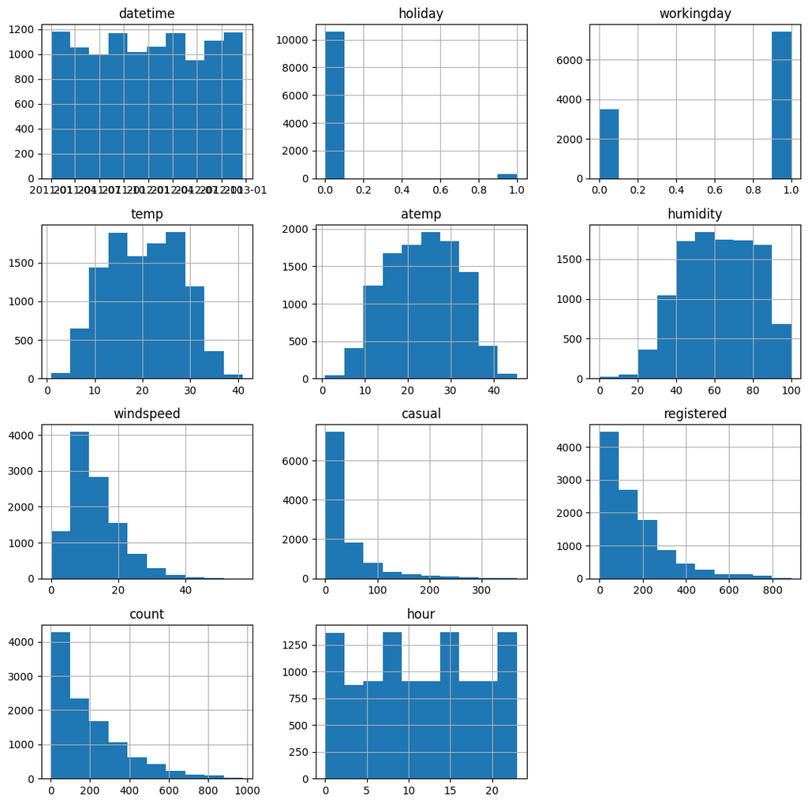

```python
# View histogram of all features again now with the hour feature
train.hist(figsize=(13, 13))
```

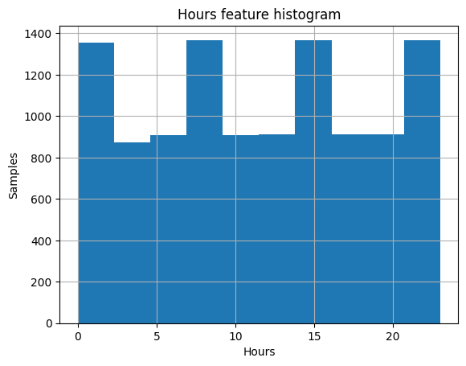

```python
# setup label for the new category and save it to a file
ax = train['hour'].hist()
ax.set_xlabel('Hours')
ax.set_ylabel('Samples')
ax.set_title('Hours feature histogram')
fig = ax.get_figure()
fig.savefig('img/hour_feature_hist.png')
```

## Step 5: Rerun the model with the same settings as before, just with more features

```python
# First I'm gomma remove registered and casual columns like before since they are not recorded in the trainset
df_train_new_feature_column = train.columns.to_list()
df_train_new_feature_column.remove('casual')
df_train_new_feature_column.remove('registered')

# Then I update and print the dataframe with the new feature column
df_train_new_feature = train[df_train_new_feature_column]
df_train_new_feature.head()
```

|  | datetime | season | holiday | workingday | weather | temp | atemp | humidity | windspeed | count | hour |
| --- | --- | --- | --- | --- | --- | --- | --- | --- | --- | --- | --- |
| 0 | 2011-01-01 00:00:00 | 1 | 0 | 0 | 1 | 9.84 | 14.395 | 81 | 0.0 | 16 | 0 |
| 1 | 2011-01-01 01:00:00 | 1 | 0 | 0 | 1 | 9.02 | 13.635 | 80 | 0.0 | 40 | 1 |
| 2 | 2011-01-01 02:00:00 | 1 | 0 | 0 | 1 | 9.02 | 13.635 | 80 | 0.0 | 32 | 2 |
| 3 | 2011-01-01 03:00:00 | 1 | 0 | 0 | 1 | 9.84 | 14.395 | 75 | 0.0 | 13 | 3 |
| 4 | 2011-01-01 04:00:00 | 1 | 0 | 0 | 1 | 9.84 | 14.395 | 75 | 0.0 | 1 | 4 |

```python
# I'll prepare the predictor by creating a new feature that contains the necessary information in a tuple.
predictor_new_feature = TabularPredictor(
    label='count',
    problem_type='regression',
    eval_metric='root_mean_squared_error').fit(
    train_data=df_train_new_feature,
    time_limit=600,
    presets='best_quality',)
```

```
No path specified. Models will be saved in: "AutogluonModels\ag-20240511_143557"
Presets specified: ['best_quality']
Setting dynamic_stacking from 'auto' to True. Reason: Enable dynamic_stacking when use_bag_holdout is disabled. (use_bag_holdout=False)
Stack configuration (auto_stack=True): num_stack_levels=1, num_bag_folds=8, num_bag_sets=1
Dynamic stacking is enabled (dynamic_stacking=True). AutoGluon will try to determine whether the input data is affected by stacked overfitting and enable or disable stacking as a consequence.
Detecting stacked overfitting by sub-fitting AutoGluon on the input data. That is, copies of AutoGluon will be sub-fit on subset(s) of the data. Then, the holdout validation data is used to detect stacked overfitting.
Sub-fit(s) time limit is: 600 seconds.
Starting holdout-based sub-fit for dynamic stacking. Context path is: AutogluonModels\ag-20240511_143557\ds_sub_fit\sub_fit_ho.
Running the sub-fit in a ray process to avoid memory leakage.
Spend 171 seconds for the sub-fit(s) during dynamic stacking.
Time left for full fit of AutoGluon: 429 seconds.
Starting full fit now with num_stack_levels 1.
Beginning AutoGluon training ... Time limit = 429s
AutoGluon will save models to "AutogluonModels\ag-20240511_143557"
=================== System Info ===================
AutoGluon Version:  1.1.0
Python Version:     3.10.6
Operating System:   Windows
Platform Machine:   AMD64
Platform Version:   10.0.19045
CPU Count:          8
Memory Avail:       7.92 GB / 15.82 GB (50.1%)
Disk Space Avail:   147.79 GB / 235.46 GB (62.8%)
===================================================
Train Data Rows:    10886
Train Data Columns: 10
Label Column:       count
Problem Type:       regression
Preprocessing data ...
Using Feature Generators to preprocess the data ...
Fitting AutoMLPipelineFeatureGenerator...
	Available Memory:                    8103.90 MB
	Train Data (Original)  Memory Usage: 0.64 MB (0.0% of available memory)
	Inferring data type of each feature based on column values. Set feature_metadata_in to manually specify special dtypes of the features.
	Stage 1 Generators:
		Fitting AsTypeFeatureGenerator...
			Note: Converting 2 features to boolean dtype as they only contain 2 unique values.
	Stage 2 Generators:
		Fitting FillNaFeatureGenerator...
	Stage 3 Generators:
```

[output cut: 93 more lines]

```
	-31.7476	 = Validation score   (-root_mean_squared_error)
	19.81s	 = Training   runtime
	0.79s	 = Validation runtime
Fitting model: CatBoost_BAG_L2 ... Training model for up to 52.51s of the 52.32s of remaining time.
	Fitting 8 child models (S1F1 - S1F8) | Fitting with ParallelLocalFoldFittingStrategy (8 workers, per: cpus=1, gpus=0, memory=0.19%)
	-30.9886	 = Validation score   (-root_mean_squared_error)
	46.61s	 = Training   runtime
	0.29s	 = Validation runtime
Fitting model: WeightedEnsemble_L3 ... Training model for up to 360.0s of the -6.59s of remaining time.
	Ensemble Weights: {'LightGBM_BAG_L2': 0.542, 'LightGBMXT_BAG_L2': 0.208, 'CatBoost_BAG_L2': 0.167, 'CatBoost_BAG_L1': 0.042, 'RandomForestMSE_BAG_L2': 0.042}
	-30.2504	 = Validation score   (-root_mean_squared_error)
	0.08s	 = Training   runtime
	0.0s	 = Validation runtime
AutoGluon training complete, total runtime = 435.76s ... Best model: "WeightedEnsemble_L3"
TabularPredictor saved. To load, use: predictor = TabularPredictor.load("AutogluonModels\ag-20240511_143557")
```

```python
predictor_new_feature.fit_summary()
```

```
*** Summary of fit() ***
Estimated performance of each model:
                     model   score_val              eval_metric  pred_time_val    fit_time  pred_time_val_marginal  fit_time_marginal  stack_level  can_infer  fit_order
0      WeightedEnsemble_L3  -30.250422  root_mean_squared_error      38.375678  337.922904                0.000997           0.081397            3       True         14
1          LightGBM_BAG_L2  -30.494052  root_mean_squared_error      36.003541  260.553507                0.548116           7.598793            2       True         11
2          CatBoost_BAG_L2  -30.988647  root_mean_squared_error      35.744534  299.569289                0.289109          46.614575            2       True         13
3        LightGBMXT_BAG_L2  -31.076997  root_mean_squared_error      36.745573  263.821130                1.290147          10.866416            2       True         10
4   RandomForestMSE_BAG_L2  -31.747623  root_mean_squared_error      36.247309  272.761723                0.791884          19.807009            2       True         12
5      WeightedEnsemble_L2  -32.296454  root_mean_squared_error      33.872738  216.054528                0.001000           0.067151            2       True          9
6          LightGBM_BAG_L1  -33.919639  root_mean_squared_error       4.548107   16.046786                4.548107          16.046786            1       True          4
7        LightGBMXT_BAG_L1  -34.457274  root_mean_squared_error      28.283372   38.760966               28.283372          38.760966            1       True          3
8          CatBoost_BAG_L1  -34.952883  root_mean_squared_error       0.386169  153.258070                0.386169         153.258070            1       True          6
9     ExtraTreesMSE_BAG_L1  -38.330568  root_mean_squared_error       0.794807    4.508955                0.794807           4.508955            1       True          7
10  RandomForestMSE_BAG_L1  -38.455347  root_mean_squared_error       0.605141    7.834505                0.605141           7.834505            1       True          5
11  NeuralNetFastAI_BAG_L1  -71.322739  root_mean_squared_error       0.740974   32.370382                0.740974          32.370382            1       True          8
12   KNeighborsDist_BAG_L1  -84.146423  root_mean_squared_error       0.048950    0.087050                0.048950           0.087050            1       True          2
13   KNeighborsUnif_BAG_L1 -101.588176  root_mean_squared_error       0.047906    0.088001                0.047906           0.088001            1       True          1
Number of models trained: 14
Types of models trained:
{'StackerEnsembleModel_RF', 'StackerEnsembleModel_KNN', 'StackerEnsembleModel_NNFastAiTabular', 'WeightedEnsembleModel', 'StackerEnsembleModel_XT', 'StackerEnsembleModel_LGB', 'StackerEnsembleModel_CatBoost'}
Bagging used: True  (with 8 folds)
Multi-layer stack-ensembling used: True  (with 3 levels)
Feature Metadata (Processed):
(raw dtype, special dtypes):
('category', [])             : 2 | ['season', 'weather']
('float', [])                : 3 | ['temp', 'atemp', 'windspeed']
('int', [])                  : 2 | ['humidity', 'hour']
('int', ['bool'])            : 2 | ['holiday', 'workingday']
('int', ['datetime_as_int']) : 5 | ['datetime', 'datetime.year', 'datetime.month', 'datetime.day', 'datetime.dayofweek']
*** End of fit() summary ***
```

[output not shown]

[output cut: 126 more lines]

```
     stack_level  can_infer  fit_order
 0             3       True         14
 1             2       True         11
 2             2       True         13
 3             2       True         10
 4             2       True         12
 5             2       True          9
 6             1       True          4
 7             1       True          3
 8             1       True          6
 9             1       True          7
 10            1       True          5
 11            1       True          8
 12            1       True          2
 13            1       True          1  }
```

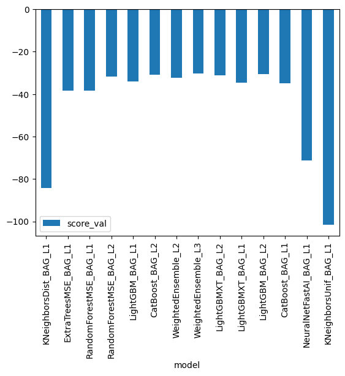

```python
# Plotting the leaderboard showing the validation scores for different models
predictor_new_feature.leaderboard(df_train_new_feature, silent=True).plot(kind='bar', x='model', y='score_val')
```

```python
# Remember to set all negative values to zero
predictions_new_features = predictor_new_feature.predict(test, as_pandas=True)
(predictions_new_features < 0).sum()
predictions_new_features[predictions_new_features < 0] = 0
```

```python
# Same submitting predictions
submission_new_features = pd.read_csv('submission.csv')
submission_new_features["count"] = predictions_new_features
submission_new_features.to_csv("submission_new_features.csv", index=False)
```

```python
!kaggle competitions submit -c bike-sharing-demand -f submission_new_features.csv -m "new features"
```

```
Successfully submitted to Bike Sharing Demand
```

```
  4%|4         | 8.00k/194k [00:00<00:13, 14.7kB/s]
```

```python
!kaggle competitions submissions -c bike-sharing-demand | tail -n +1 | head -n 6
```

[output not shown]

#### New Score of `0.61728`

## Step 6: Hyper parameter optimization

- There are many options for hyper parameter optimization.
- Options are to change the AutoGluon higher level parameters or the individual model hyperparameters.
- The hyperparameters of the models themselves that are in AutoGluon. Those need the `hyperparameter` and `hyperparameter_tune_kwargs` arguments.

```python
from autogluon.common import space as ag

# Definition of options for Gradient Boosting Machine (GBM)
gbm_options = {
    'number_boost_round': ag.Int(lower=100, upper=500, default=100),
    'number_leaves': ag.Int(lower=6, upper=10),
    'learning_rate': ag.Real(lower=0.01, upper=0.3, log=True)  # Using logarithmic scale for learning rate
}

# Definition of options for CatBoost (CAT)
cat_options = {
    'iterations': 100,
    'learning_rate': ag.Real(lower=0.01, upper=0.3, log=True),
    'depth': ag.Int(lower=6, upper=10)
}

# Definition of options for XGBoost (XGB)
xgb_options = {
    'n_estimators': ag.Int(lower=100, upper=500, default=100),
    'max_depth': ag.Int(lower=6, upper=10, default=6),
    'eta': ag.Real(lower=0.01, upper=0.3, log=True)  # Using logarithmic scale for eta
}
```

```python
# Definition of hyperparameter search options
hyperparameters = {
    'XGB': xgb_options,
    'GBM': gbm_options,
    'CAT': cat_options
}

# Number of trials for hyperparameter optimization
num_trials = 5
# Search strategy for hyperparameters (in this case 'random')
search_strategy = 'random'

# Parameters for hyperparameter tuning
hyperparameter_tune_kwargs = {
    'num_trials': num_trials,
    'scheduler': 'local',
    'searcher': search_strategy
}
```

```python
# Training the model with hyperparameter optimization using AutoGluon
predictor_new_hpo = TabularPredictor(
    label='count',
    problem_type='regression',
    eval_metric='root_mean_squared_error',
    path='AutogluonModels/xgb_gbm_cat_tuning_v1'
).fit(
    train_data=df_train_new_feature,
    time_limit=600,  # Time limit for training in seconds
    presets='best_quality',  # Using preset settings for best quality
    hyperparameters=hyperparameters,
    hyperparameter_tune_kwargs=hyperparameter_tune_kwargs,
)
```

```
Presets specified: ['best_quality']
Warning: hyperparameter tuning is currently experimental and may cause the process to hang.
Setting dynamic_stacking from 'auto' to True. Reason: Enable dynamic_stacking when use_bag_holdout is disabled. (use_bag_holdout=False)
Stack configuration (auto_stack=True): num_stack_levels=1, num_bag_folds=8, num_bag_sets=1
Dynamic stacking is enabled (dynamic_stacking=True). AutoGluon will try to determine whether the input data is affected by stacked overfitting and enable or disable stacking as a consequence.
Detecting stacked overfitting by sub-fitting AutoGluon on the input data. That is, copies of AutoGluon will be sub-fit on subset(s) of the data. Then, the holdout validation data is used to detect stacked overfitting.
Sub-fit(s) time limit is: 600 seconds.
Starting holdout-based sub-fit for dynamic stacking. Context path is: AutogluonModels/xgb_gbm_cat_tuning_v1\ds_sub_fit\sub_fit_ho.
Running the sub-fit in a ray process to avoid memory leakage.
Spend 180 seconds for the sub-fit(s) during dynamic stacking.
Time left for full fit of AutoGluon: 420 seconds.
Starting full fit now with num_stack_levels 1.
Beginning AutoGluon training ... Time limit = 420s
AutoGluon will save models to "AutogluonModels/xgb_gbm_cat_tuning_v1"
=================== System Info ===================
AutoGluon Version:  1.1.0
Python Version:     3.10.6
Operating System:   Windows
Platform Machine:   AMD64
Platform Version:   10.0.19045
CPU Count:          8
Memory Avail:       7.52 GB / 15.82 GB (47.6%)
Disk Space Avail:   146.73 GB / 235.46 GB (62.3%)
===================================================
Train Data Rows:    10886
Train Data Columns: 10
Label Column:       count
Problem Type:       regression
Preprocessing data ...
Using Feature Generators to preprocess the data ...
Fitting AutoMLPipelineFeatureGenerator...
	Available Memory:                    7687.17 MB
	Train Data (Original)  Memory Usage: 0.64 MB (0.0% of available memory)
	Inferring data type of each feature based on column values. Set feature_metadata_in to manually specify special dtypes of the features.
	Stage 1 Generators:
		Fitting AsTypeFeatureGenerator...
			Note: Converting 2 features to boolean dtype as they only contain 2 unique values.
	Stage 2 Generators:
		Fitting FillNaFeatureGenerator...
	Stage 3 Generators:
```

[output cut: 20 more lines]

```
	10 features in original data used to generate 14 features in processed data.
	Train Data (Processed) Memory Usage: 0.83 MB (0.0% of available memory)
Data preprocessing and feature engineering runtime = 0.34s ...
AutoGluon will gauge predictive performance using evaluation metric: 'root_mean_squared_error'
	This metric's sign has been flipped to adhere to being higher_is_better. The metric score can be multiplied by -1 to get the metric value.
	To change this, specify the eval_metric parameter of Predictor()
User-specified model hyperparameters to be fit:
{
	'XGB': {'n_estimators': Int: lower=100, upper=500, 'max_depth': Int: lower=6, upper=10, 'eta': Real: lower=0.01, upper=0.3},
	'GBM': {'number_boost_round': Int: lower=100, upper=500, 'number_leaves': Int: lower=6, upper=10, 'learning_rate': Real: lower=0.01, upper=0.3},
	'CAT': {'iterations': 100, 'learning_rate': Real: lower=0.01, upper=0.3, 'depth': Int: lower=6, upper=10},
}
AutoGluon will fit 2 stack levels (L1 to L2) ...
Fitting 3 L1 models ...
Hyperparameter tuning model: LightGBM_BAG_L1 ... Tuning model for up to 83.91s of the 419.65s of remaining time.
```

```
	Fitting 8 child models (S1F1 - S1F8) | Fitting with ParallelLocalFoldFittingStrategy (8 workers, per: cpus=1, gpus=0, memory=0.10%)
	Stopping HPO to satisfy time limit...
Fitted model: LightGBM_BAG_L1\T1 ...
	-33.8624	 = Validation score   (-root_mean_squared_error)
	70.76s	 = Training   runtime
	0.0s	 = Validation runtime
Hyperparameter tuning model: CatBoost_BAG_L1 ... Tuning model for up to 83.91s of the 348.6s of remaining time.
```

```
	Fitting 8 child models (S1F1 - S1F8) | Fitting with ParallelLocalFoldFittingStrategy (8 workers, per: cpus=1, gpus=0, memory=0.14%)
	Fitting 8 child models (S1F1 - S1F8) | Fitting with ParallelLocalFoldFittingStrategy (8 workers, per: cpus=1, gpus=0, memory=1.10%)
	Fitting 8 child models (S1F1 - S1F8) | Fitting with ParallelLocalFoldFittingStrategy (8 workers, per: cpus=1, gpus=0, memory=0.58%)
	Stopping HPO to satisfy time limit...
Fitted model: CatBoost_BAG_L1\T1 ...
	-112.9033	 = Validation score   (-root_mean_squared_error)
	23.0s	 = Training   runtime
	0.0s	 = Validation runtime
Fitted model: CatBoost_BAG_L1\T2 ...
	-36.0601	 = Validation score   (-root_mean_squared_error)
	30.77s	 = Training   runtime
	0.0s	 = Validation runtime
Fitted model: CatBoost_BAG_L1\T3 ...
	-46.9577	 = Validation score   (-root_mean_squared_error)
	30.39s	 = Training   runtime
	0.0s	 = Validation runtime
Hyperparameter tuning model: XGBoost_BAG_L1 ... Tuning model for up to 83.91s of the 264.15s of remaining time.
```

```
	Fitting 8 child models (S1F1 - S1F8) | Fitting with ParallelLocalFoldFittingStrategy (8 workers, per: cpus=1, gpus=0, memory=0.15%)
	Fitting 8 child models (S1F1 - S1F8) | Fitting with ParallelLocalFoldFittingStrategy (8 workers, per: cpus=1, gpus=0, memory=0.35%)
	Fitting 8 child models (S1F1 - S1F8) | Fitting with ParallelLocalFoldFittingStrategy (8 workers, per: cpus=1, gpus=0, memory=0.16%)
	Fitting 8 child models (S1F1 - S1F8) | Fitting with ParallelLocalFoldFittingStrategy (8 workers, per: cpus=1, gpus=0, memory=0.23%)
	Stopping HPO to satisfy time limit...
Fitted model: XGBoost_BAG_L1\T1 ...
	-38.0328	 = Validation score   (-root_mean_squared_error)
	16.81s	 = Training   runtime
	0.0s	 = Validation runtime
Fitted model: XGBoost_BAG_L1\T2 ...
	-36.1378	 = Validation score   (-root_mean_squared_error)
	19.46s	 = Training   runtime
	0.0s	 = Validation runtime
Fitted model: XGBoost_BAG_L1\T3 ...
	-35.288	 = Validation score   (-root_mean_squared_error)
	16.89s	 = Training   runtime
	0.0s	 = Validation runtime
Fitted model: XGBoost_BAG_L1\T4 ...
	-36.1841	 = Validation score   (-root_mean_squared_error)
	20.2s	 = Training   runtime
	0.0s	 = Validation runtime
Fitting model: WeightedEnsemble_L2 ... Training model for up to 360.0s of the 190.46s of remaining time.
	Ensemble Weights: {'LightGBM_BAG_L1\T1': 0.522, 'CatBoost_BAG_L1\T2': 0.217, 'XGBoost_BAG_L1\T2': 0.13, 'XGBoost_BAG_L1\T3': 0.13}
	-33.0501	 = Validation score   (-root_mean_squared_error)
	0.08s	 = Training   runtime
	0.0s	 = Validation runtime
Fitting 3 L2 models ...
Hyperparameter tuning model: LightGBM_BAG_L2 ... Tuning model for up to 57.09s of the 190.27s of remaining time.
```

```
	Fitting 8 child models (S1F1 - S1F8) | Fitting with ParallelLocalFoldFittingStrategy (8 workers, per: cpus=1, gpus=0, memory=0.14%)
	Fitting 8 child models (S1F1 - S1F8) | Fitting with ParallelLocalFoldFittingStrategy (8 workers, per: cpus=1, gpus=0, memory=0.23%)
	Stopping HPO to satisfy time limit...
Fitted model: LightGBM_BAG_L2\T1 ...
	-33.5536	 = Validation score   (-root_mean_squared_error)
	22.0s	 = Training   runtime
	0.0s	 = Validation runtime
Fitted model: LightGBM_BAG_L2\T2 ...
	-34.1264	 = Validation score   (-root_mean_squared_error)
	19.81s	 = Training   runtime
	0.0s	 = Validation runtime
Hyperparameter tuning model: CatBoost_BAG_L2 ... Tuning model for up to 57.09s of the 148.25s of remaining time.
```

```
	Fitting 8 child models (S1F1 - S1F8) | Fitting with ParallelLocalFoldFittingStrategy (8 workers, per: cpus=1, gpus=0, memory=0.20%)
	Fitting 8 child models (S1F1 - S1F8) | Fitting with ParallelLocalFoldFittingStrategy (8 workers, per: cpus=1, gpus=0, memory=1.75%)
	Stopping HPO to satisfy time limit...
Fitted model: CatBoost_BAG_L2\T1 ...
	-77.5436	 = Validation score   (-root_mean_squared_error)
	26.76s	 = Training   runtime
	0.0s	 = Validation runtime
Fitted model: CatBoost_BAG_L2\T2 ...
	-34.4068	 = Validation score   (-root_mean_squared_error)
	37.1s	 = Training   runtime
	0.0s	 = Validation runtime
Hyperparameter tuning model: XGBoost_BAG_L2 ... Tuning model for up to 57.09s of the 84.22s of remaining time.
```

```
	Fitting 8 child models (S1F1 - S1F8) | Fitting with ParallelLocalFoldFittingStrategy (8 workers, per: cpus=1, gpus=0, memory=0.23%)
	Fitting 8 child models (S1F1 - S1F8) | Fitting with ParallelLocalFoldFittingStrategy (8 workers, per: cpus=1, gpus=0, memory=0.54%)
	Stopping HPO to satisfy time limit...
Fitted model: XGBoost_BAG_L2\T1 ...
	-33.7315	 = Validation score   (-root_mean_squared_error)
	19.3s	 = Training   runtime
	0.0s	 = Validation runtime
Fitted model: XGBoost_BAG_L2\T2 ...
	-34.4445	 = Validation score   (-root_mean_squared_error)
	24.15s	 = Training   runtime
	0.0s	 = Validation runtime
Fitting model: WeightedEnsemble_L3 ... Training model for up to 360.0s of the 40.54s of remaining time.
	Ensemble Weights: {'LightGBM_BAG_L1\T1': 0.36, 'CatBoost_BAG_L1\T2': 0.16, 'LightGBM_BAG_L2\T2': 0.12, 'XGBoost_BAG_L2\T1': 0.12, 'XGBoost_BAG_L1\T2': 0.08, 'XGBoost_BAG_L1\T3': 0.08, 'LightGBM_BAG_L2\T1': 0.04, 'CatBoost_BAG_L2\T2': 0.04}
	-32.9537	 = Validation score   (-root_mean_squared_error)
	0.09s	 = Training   runtime
	0.0s	 = Validation runtime
AutoGluon training complete, total runtime = 379.71s ... Best model: "WeightedEnsemble_L3"
TabularPredictor saved. To load, use: predictor = TabularPredictor.load("AutogluonModels/xgb_gbm_cat_tuning_v1")
```

```python
predictor_new_hpo.fit_summary()
```

```
*** Summary of fit() ***
Estimated performance of each model:
                  model   score_val              eval_metric  pred_time_val    fit_time  pred_time_val_marginal  fit_time_marginal  stack_level  can_infer  fit_order
0   WeightedEnsemble_L3  -32.953735  root_mean_squared_error       0.002667  326.585774                0.000000           0.085160            3       True         16
1   WeightedEnsemble_L2  -33.050146  root_mean_squared_error       0.002765  137.966268                0.002090           0.077917            2       True          9
2    LightGBM_BAG_L2\T1  -33.553594  root_mean_squared_error       0.002667  250.285777                0.000000          21.996350            2       True         10
3     XGBoost_BAG_L2\T1  -33.731484  root_mean_squared_error       0.002667  247.590746                0.000000          19.301319            2       True         14
4    LightGBM_BAG_L1\T1  -33.862368  root_mean_squared_error       0.000000   70.762331                0.000000          70.762331            1       True          1
5    LightGBM_BAG_L2\T2  -34.126420  root_mean_squared_error       0.002667  248.102529                0.000000          19.813103            2       True         11
6    CatBoost_BAG_L2\T2  -34.406766  root_mean_squared_error       0.002667  265.389842                0.000000          37.100415            2       True         13
7     XGBoost_BAG_L2\T2  -34.444478  root_mean_squared_error       0.002667  252.436538                0.000000          24.147111            2       True         15
8     XGBoost_BAG_L1\T3  -35.287965  root_mean_squared_error       0.000675   16.889918                0.000675          16.889918            1       True          7
9    CatBoost_BAG_L1\T2  -36.060110  root_mean_squared_error       0.000000   30.774307                0.000000          30.774307            1       True          3
10    XGBoost_BAG_L1\T2  -36.137772  root_mean_squared_error       0.000000   19.461794                0.000000          19.461794            1       True          6
11    XGBoost_BAG_L1\T4  -36.184075  root_mean_squared_error       0.000998   20.199718                0.000998          20.199718            1       True          8
12    XGBoost_BAG_L1\T1  -38.032810  root_mean_squared_error       0.000993   16.811004                0.000993          16.811004            1       True          5
13   CatBoost_BAG_L1\T3  -46.957733  root_mean_squared_error       0.000000   30.388916                0.000000          30.388916            1       True          4
14   CatBoost_BAG_L2\T1  -77.543580  root_mean_squared_error       0.003476  255.054063                0.000809          26.764637            2       True         12
15   CatBoost_BAG_L1\T1 -112.903265  root_mean_squared_error       0.000000   23.001438                0.000000          23.001438            1       True          2
Number of models trained: 16
Types of models trained:
{'WeightedEnsembleModel', 'StackerEnsembleModel_LGB', 'StackerEnsembleModel_XGBoost', 'StackerEnsembleModel_CatBoost'}
Bagging used: True  (with 8 folds)
Multi-layer stack-ensembling used: True  (with 3 levels)
Feature Metadata (Processed):
(raw dtype, special dtypes):
('category', [])             : 2 | ['season', 'weather']
('float', [])                : 3 | ['temp', 'atemp', 'windspeed']
('int', [])                  : 2 | ['humidity', 'hour']
('int', ['bool'])            : 2 | ['holiday', 'workingday']
('int', ['datetime_as_int']) : 5 | ['datetime', 'datetime.year', 'datetime.month', 'datetime.day', 'datetime.dayofweek']
*** End of fit() summary ***
```

[output not shown]

[output cut: 145 more lines]

```
 1        True          9
 2        True         10
 3        True         14
 4        True          1
 5        True         11
 6        True         13
 7        True         15
 8        True          7
 9        True          3
 10       True          6
 11       True          8
 12       True          5
 13       True          4
 14       True         12
 15       True          2  }
```

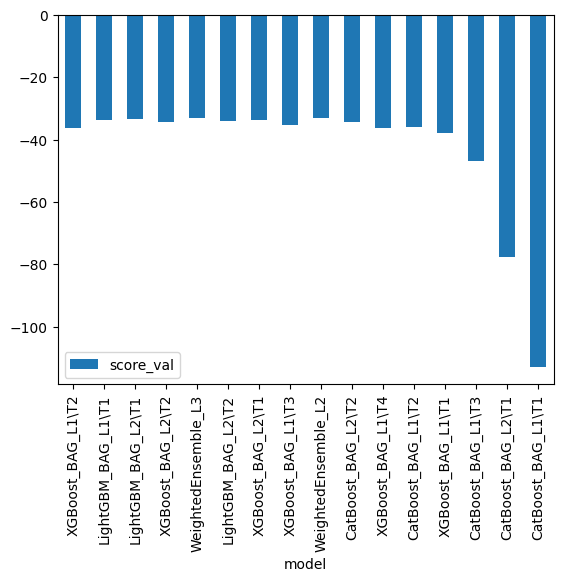

```python
# # Plotting the leaderboard showing the validation scores for different models
predictor_new_hpo.leaderboard(df_train_new_feature, silent=True).plot(kind='bar',x='model',y='score_val')
```

```python
# Rememer to set all negative values to zero
predictions_new_hpo = predictor_new_hpo.predict(test, as_pandas=True)
```

```python
(predictions_new_hpo < 0).sum()
```

predictions_new_hpo[predictions_new_hpo < 0] = 0

```python
# Same submitting predictions
submission_new_hpo = submission
submission_new_hpo["count"] = predictions_new_hpo
submission_new_hpo.to_csv("submission_new_hpo.csv", index=False)
```

```python
!kaggle competitions submit -c bike-sharing-demand -f submission_new_hpo.csv -m "new features with hyperparameters"
```

```
Successfully submitted to Bike Sharing Demand
```

```
  4%|4         | 8.00k/195k [00:00<00:12, 15.3kB/s]
```

```python
!kaggle competitions submissions -c bike-sharing-demand | tail -n +1 | head -n 6
```

[output not shown]

#### New Score of `0.51354`

## Step 7: Write a Report

### Refer to the markdown file for the full report

### Creating plots and table for report

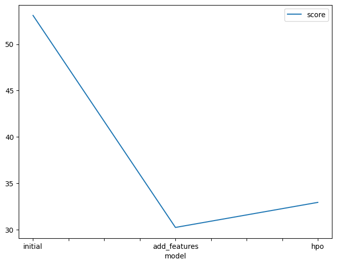

```python
# Taking the top model score from each training run and creating a line plot to show improvement
# You can create these in the notebook and save them to PNG or use some other tool (e.g. google sheets, excel)
fig = pd.DataFrame(
    {
        "model": ["initial", "add_features", "hpo"],
        "score": [53.10, 30.25, 32.95]
    }
).plot(x="model", y="score", figsize=(8, 6)).get_figure()
fig.savefig('model_train_score.png')
```

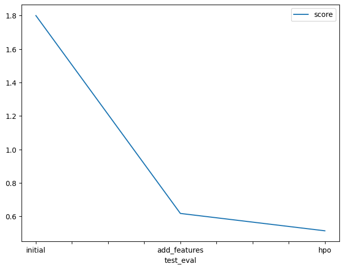

```python
# Take the 3 kaggle scores and creating a line plot to show improvement
fig = pd.DataFrame({
    "test_eval": ["initial", "add_features", "hpo"],
    "score": [1.79947, 0.61728, 0.51354]
}).plot(x="test_eval", y="score", figsize=(8, 6)).get_figure()
fig.savefig('model_train_score.png')
```

### Hyperparameter table

```python
# The 3 hyperparameters we tuned with the kaggle score as the result
df_table = pd.DataFrame({
    "model": ["initial", "add_features", "hpo"],
    "hpo1": [
        'default_vals',
        'default_vals',
        'GBM (Light gradient boosting) : num_boost_round: [lower=100, upper=500], num_leaves:[lower=6, upper=10], learning_rate:[lower=0.01, upper=0.3, log scale], applying random search with 5 trials'
            ],
    "hpo2": [
        'default_vals',
        'default_vals',
        'XGB (XGBoost): n_estimators : [lower=100, upper=500], max_depth : [lower=6, upper=10], eta (learning_rate) : [lower=0.01, upper=0.3, log scale] applying random search with 5 trials'
        ],
    "hpo3": [
        'default_vals',
        'default_vals',
        'CAT (CATBoost) : iterations : 100, depth : [lower=6, upper=10], learning_rate  : [lower=0.01, upper=0.3, log scale] applying random search with 5 trials'
    ],
    "score": [1.79947, 0.61728, 0.51354]
})
```

```python
print(df_table.to_markdown())
```

```
|    | model        | hpo1                                                                                                                                                                                            | hpo2                                                                                …
|---:|:-------------|:------------------------------------------------------------------------------------------------------------------------------------------------------------------------------------------------|:------------------------------------------------------------------------------------…
|  0 | initial      | default_vals                                                                                                                                                                                    | default_vals                                                                        …
|  1 | add_features | default_vals                                                                                                                                                                                    | default_vals                                                                        …
|  2 | hpo          | GBM (Light gradient boosting) : num_boost_round: [lower=100, upper=500], num_leaves:[lower=6, upper=10], learning_rate:[lower=0.01, upper=0.3, log scale], applying random search with 5 trials | XGB (XGBoost): n_estimators : [lower=100, upper=500], max_depth : [lower=6, upper=10…
```